# Homework #2: Resampling

Hyunsuk Ko

Due: Wed Sept 14 | 11:45am

**DS 6030 | Fall 2022 | University of Virginia**

# Required R packages and Directories

```r
data.dir = 'https://mdporter.github.io/DS6030/data/' # data directory
library(R6030)     # functions for DS-6030
library(tidyverse) # functions for data manipulation
library(splines)
library(FNN)
rm(list = ls())
```

# Problem 1: Bootstrapping

Bootstrap resampling can be used to quantify the uncertainty in a fitted curve.

## a. Create a set of functions to generate data from the following distributions:

$$\begin{align*}
X &\sim \mathcal{U}(0, 2) \qquad \text{Uniform in $[0,2]$}\\
Y &= 1 + 2x + 5\sin(5x) + \epsilon \\
\epsilon &\sim \mathcal{N}(0,\, \sigma=2.5)
\end{align*}$$

```r
sim_x <- function(n) runif(n, min = 0, max = 2)
sim_y <- function(x){               # generate Y|X from N{f(x),sd}
  n = length(x)
  f <- function(x) 1 + 2 * x + 5 * sin(5 * x)
  f(x) + rnorm(n, mean = 0 , sd = 2.5)  # error
}
```

## b. Simulate $n=100$ realizations from these distributions. Produce a scatterplot and draw the true regression line $f(x) = E[Y \mid X=x]$. Use `set.seed(211)` prior to generating the data.

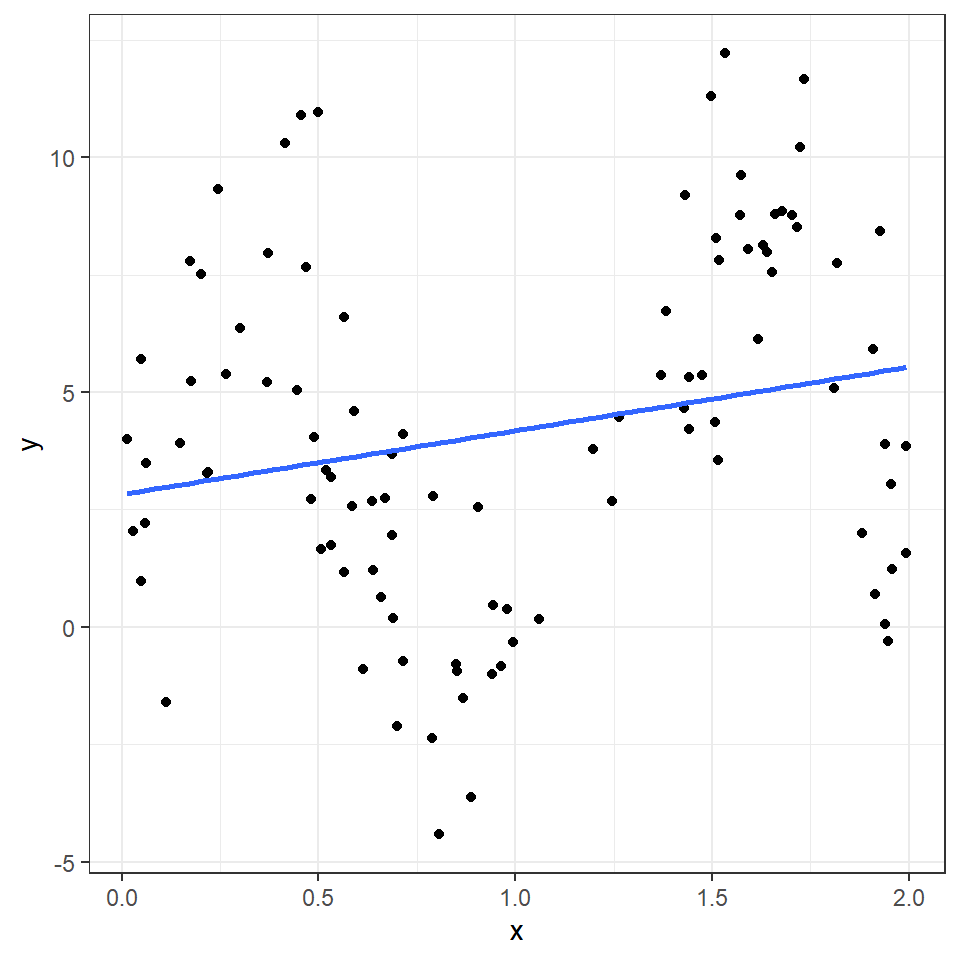

```r
set.seed(211)

n <- 100

x <- sim_x(n)    # get x values
y <- sim_y(x)

data_train <- tibble(x, y)               # training data tibble

gg_myplot <- ggplot(data_train, aes(x = x, y = y)) +
  geom_point() +
  geom_smooth(method = "lm", se = FALSE)

gg_myplot
```

## c. Fit a 5th degree polynomial. Produce a scatterplot and draw the *estimated* regression curve.

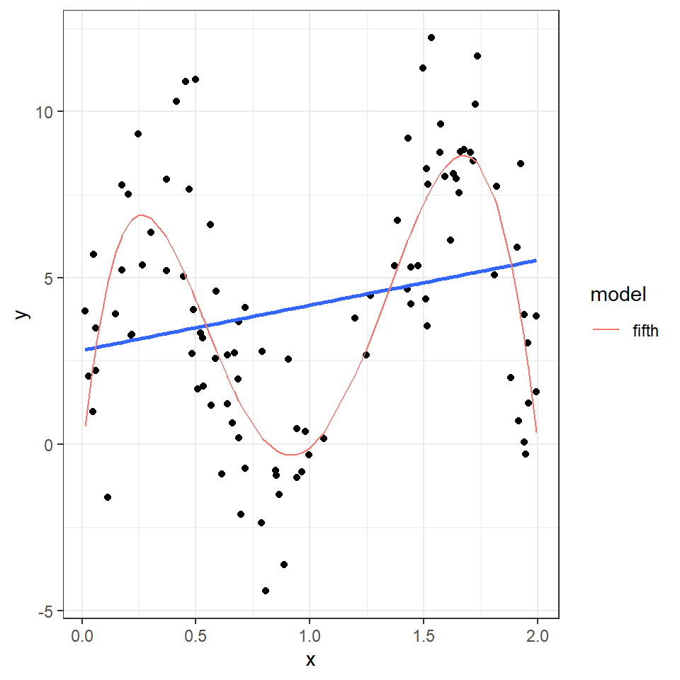

```r
xseq <- x
xeval <- tibble(x = xseq)

m5 <- lm(y~poly(x, degree=5), data = data_train)
yhat5 <- predict(m5, newdata =xeval)

fifth.data <- tibble(x = xseq, fifth = yhat5) %>%  # long data
  pivot_longer(-x, names_to="model", values_to="y")

gg_myplot +
  geom_line(data=fifth.data, aes(color=model))
```

## d. Make 200 bootstrap samples. For each bootstrap sample, fit a 5th degree polynomial and make predictions at `eval_pts = seq(0, 2, length=100)`

- Set the seed (use `set.seed(212)`) so your results are reproducible.
- Produce a scatterplot with the original data and add the 200 bootstrap curves

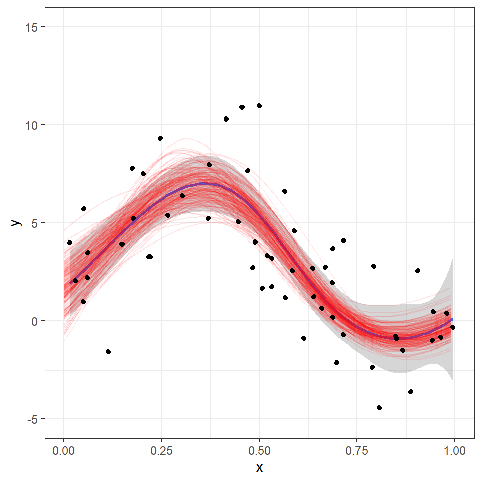

```r
set.seed(212)

n <- length(x) # length of observed data
M <- 200 # number of bootstrap samples
p <- numeric(M) # initialize vector for test statistic
data_eval<- tibble(x = seq(0,2,length=100)) # evaluation points
YHAT <- matrix(NA, nrow(data_eval), M)
kts_bdry <- c(-.2,1.2)

for (m in 1:M) {
  ind = sample(n, replace = TRUE)  # sample indices with replacement
  xboot = x[ind]                   # bootstrap sample
  p[m] = mean(xboot)
  m_boot = lm(y ~ bs(x, df = 5, Boundary.knots = kts_bdry)-1, data = data_train[ind,]) # fit bootstrap data
  # predict from bootstrap model
  YHAT[,m] = predict(m_boot, data_eval)
}
#print(YHAT)

data_fit <- as_tibble(YHAT) %>% # convert matrix into tibble
  bind_cols(data_eval) %>%      # add the eval points
  pivot_longer(-x, names_to = "simulation", values_to = "y") # convert to long format

ggplot(data_train, aes(x,y)) +
  geom_smooth(method = "lm", formula = as.formula('y~bs(x, df=5, deg=3, Boundary.knots = kts_bdry)-1')) +
  geom_line(data=data_fit, color="red", alpha=.1, aes(group=simulation)) +
  geom_point() +
  scale_x_continuous(limits = c(0, 1)) +
  scale_y_continuous(limits = c(-5,15))
```

## e. Calculate the pointwise 95% confidence intervals from the bootstrap samples. That is, for each $x \in {\rm eval\_pts}$, calculate the upper and lower limits such that only 5% of the curves fall outside the interval at $x$.

- Remake the plot from part *c*, but add the upper and lower boundaries from the 95% confidence intervals.

```r
quantile(p, probs = c(.025, .975)) # 95% bootstrap interval
```

```
#>   2.5%  97.5%
#> 0.8938 1.1181
```

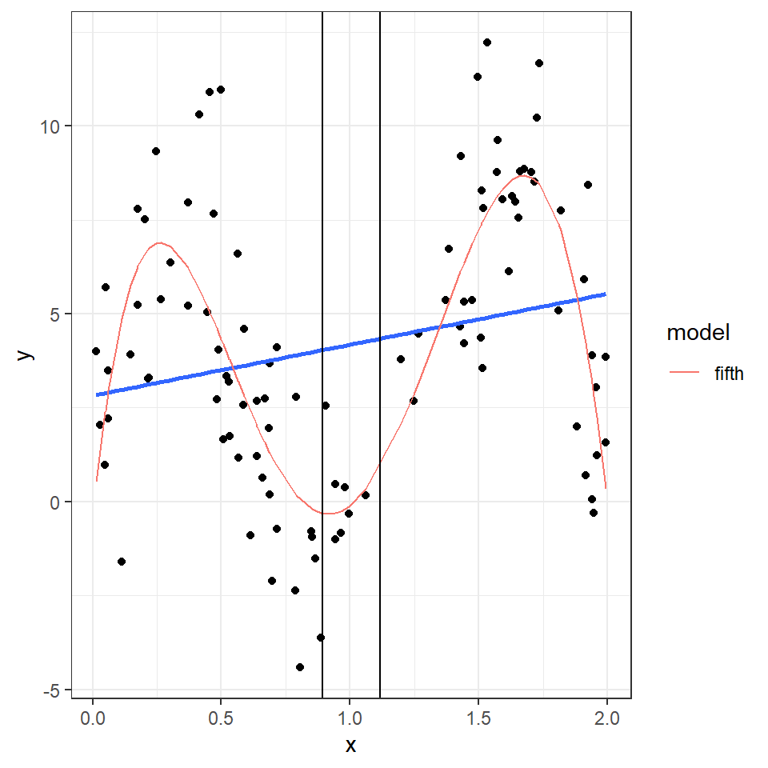

```r
gg_myplot +
  geom_line(data=fifth.data, aes(color=model)) +
  geom_vline(xintercept = quantile(p, probs = c(.025, .975))[1]) +
  geom_vline(xintercept = quantile(p, probs = c(.025, .975))[2])
```

# Problem 2: V-Fold cross-validation with $k$ nearest neighbors

Run 10-fold cross-validation on the data generated in part 1b to select the optimal $k$ in a k-nearest neighbor (kNN) model. Then evaluate how well cross-validation performed by evaluating the performance on a large test set. The steps below will guide you.

## a. Use $10$-fold cross-validation to find the value of $k$ (i.e., neighborhood size) that provides the smallest cross-validated MSE using a kNN model.

- Search over $k=3,4,\ldots, 40$.
- Use `set.seed(221)` prior to generating the folds to ensure the results are replicable.
- Show the following:
  - the optimal $k$ (as determined by cross-validation)
  - the corresponding estimated MSE
  - produce a plot with $k$ on the x-axis and the estimated MSE on the y-axis (optional: add 1-standard error bars).
- Notation: The $k$ is the tuning paramter for the kNN model. The $v=10$ is the number of folds in V-fold cross-validation. Don’t get yourself confused.

```r
knn_eval <- function(k, data_train, data_test){
  # fit model and eval on training data
  knn = knn.reg(data_train[,'x', drop=FALSE],
                y = data_train$y,
                test = data_train[,'x', drop=FALSE],
                k = k)
  r = data_train$y- knn$pred      # residuals on training data
  mse.train = mean(r^2)            # training MSE

  # fit model and eval on test data
  knn.test = knn.reg(data_train[,'x', drop=FALSE],
                     y = data_train$y,
                     test=data_test[,'x', drop=FALSE],
                     k=k)
  r.test = data_test$y - knn.test$pred # residuals on test data
  mse.test = mean(r.test^2)          # test MSE
    # results
  edf = nrow(data_train)/k         # effective dof (edof)
  tibble(k=k, edf=edf, mse.train, mse.test)
}
```

```r
n <- nrow(data_train) # number of training observations (= 100)
n.folds <- 10 # number of folds for cross-validation
set.seed(221)
fold <- sample(rep(1:n.folds, length = n)) # vector of fold labels
data_knn = tibble()

# Iterate over folds
for (j in 1:n.folds) {
  # Set training / val data
  val = which(fold == j) # indices of holdout / validation data
  train = which(fold != j) # indices of fitting / training data
  n.val = length(val) # number of observations in validation

  # Fit and evaluate models
  K = seq(3,40,1)
  for(k in K){
    tmp = knn_eval(k, data_train= slice(data_train,train), data_test= slice(data_train, val))
    data_knn = bind_rows(data_knn, tmp)
  }
}

df_result <- data_knn %>% group_by(k) %>%
  summarize(mse = mean(mse.test), sd = sd(mse.test), se = sd / sqrt(n)) %>%
  arrange(mse)
df_result
```

| k | mse | sd | se |
| --- | --- | --- | --- |
| 8 | 5.937 | 1.885 | 0.1885 |
| 9 | 6.028 | 1.788 | 0.1788 |
| 11 | 6.085 | 1.961 | 0.1961 |
| 6 | 6.139 | 2.000 | 0.2000 |
| 7 | 6.181 | 1.866 | 0.1866 |
| 10 | 6.211 | 1.879 | 0.1879 |
| 12 | 6.308 | 1.781 | 0.1781 |
| 13 | 6.554 | 1.981 | 0.1981 |
| 5 | 6.559 | 2.078 | 0.2078 |
| 14 | 6.714 | 1.963 | 0.1963 |

[output cut: 28 more lines]

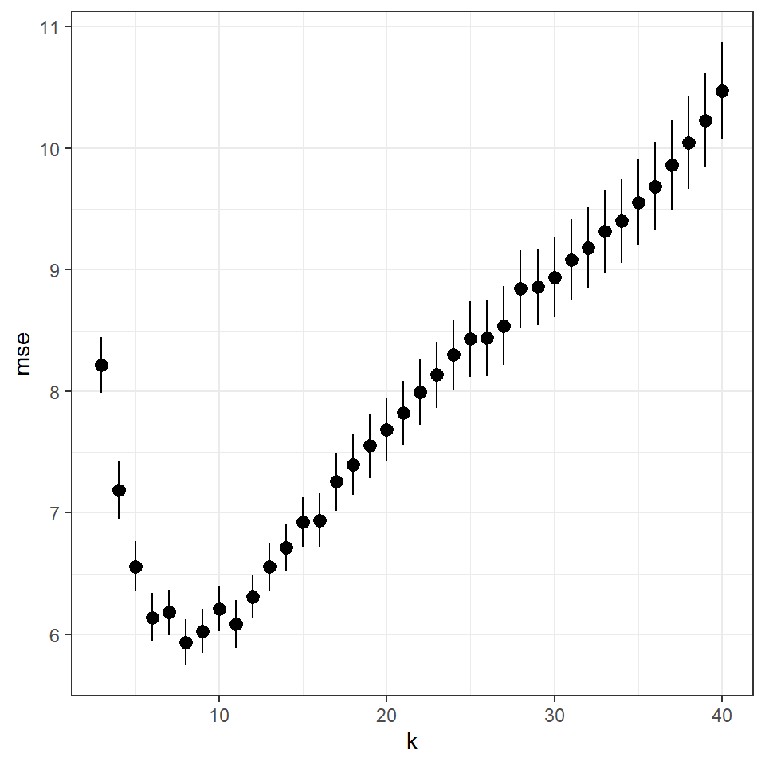

```r
ggplot(df_result, aes(x=k, y = mse)) +
  geom_pointrange(aes(ymin = mse-se, ymax = mse+se))
```

## b. The $k$ (number of neighbors) in a kNN model determines the effective degrees of freedom *edf*. What is the optimal *edf*? Be sure to use the correct sample size when making this calculation. Produce a plot similar to that from part *a*, but use *edf* (effective degrees of freedom) on the x-axis.

: Our optimal *edf* = 11.250

```r
df_edf <- df_result %>%
  mutate(edf = 90 / k)
df_edf
```

| k | mse | sd | se | edf |
| --- | --- | --- | --- | --- |
| 8 | 5.937 | 1.885 | 0.1885 | 11.250 |
| 9 | 6.028 | 1.788 | 0.1788 | 10.000 |
| 11 | 6.085 | 1.961 | 0.1961 | 8.182 |
| 6 | 6.139 | 2.000 | 0.2000 | 15.000 |
| 7 | 6.181 | 1.866 | 0.1866 | 12.857 |
| 10 | 6.211 | 1.879 | 0.1879 | 9.000 |
| 12 | 6.308 | 1.781 | 0.1781 | 7.500 |
| 13 | 6.554 | 1.981 | 0.1981 | 6.923 |
| 5 | 6.559 | 2.078 | 0.2078 | 18.000 |
| 14 | 6.714 | 1.963 | 0.1963 | 6.429 |

[output cut: 28 more lines]

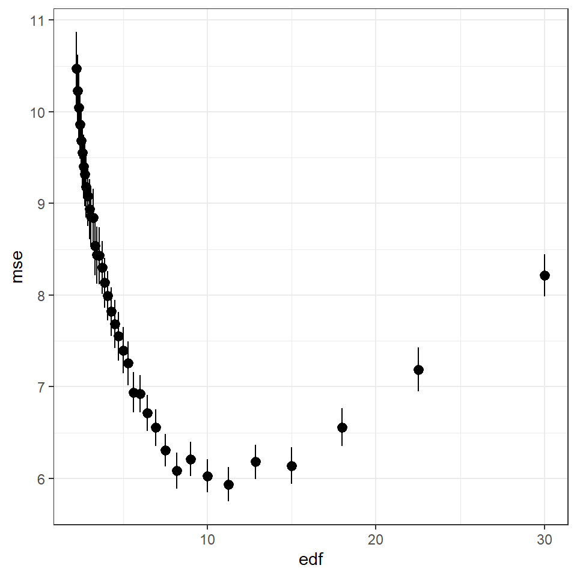

```r
ggplot(df_edf, aes(x = edf, y = mse)) +
  geom_pointrange(aes(ymin = mse-se, ymax = mse+se))
```

## c. After running cross-validation, a final model fit from *all* of the training data needs to be produced to make predictions. What value of $k$ would you choose? Why?

As k = 8 gives the lowest mean test MSE, this will be our optimal k.

## d. Now we will see how well cross-validation performed. Simulate a test data set of $50000$ observations from the same distributions. Use `set.seed(223)` prior to generating the test data.

- Fit a set of kNN models, using the full training data, and calculate the mean squared error (MSE) on the test data for each model. Use the same $k$ values in *a*.
- Report the optimal $k$, the corresponding *edf*, and MSE based on the test set.

: Our optimal $k = 13$, *edf* = 7.692, and test MSE = 7.109

```r
ntest <- 50000                          # Number of test samples
set.seed(223)                           # set *different* seed
xtest = sim_x(ntest)                    # generate test X's
ytest = sim_y(xtest)             # generate test Y's
data_test = tibble(x=xtest, y=ytest)    # test data
```

```r
data_knn2 = tibble()
K = seq(3,40,1)
for(k in K){
  tmp = knn_eval(k, data_train= data_train, data_test= data_test)
  data_knn2 = bind_rows(data_knn2, tmp)
}

data_knn2 %>% arrange(by = mse.test)
```

| k | edf | mse.train | mse.test |
| --- | --- | --- | --- |
| 13 | 7.692 | 5.170 | 7.109 |
| 12 | 8.333 | 5.117 | 7.126 |
| 8 | 12.500 | 4.799 | 7.144 |
| 10 | 10.000 | 4.835 | 7.147 |
| 11 | 9.091 | 5.023 | 7.169 |
| 9 | 11.111 | 4.846 | 7.188 |
| 14 | 7.143 | 5.396 | 7.205 |
| 7 | 14.286 | 4.710 | 7.258 |
| 15 | 6.667 | 5.566 | 7.284 |
| 6 | 16.667 | 4.697 | 7.303 |

[output cut: 28 more lines]

## e. Plot both the cross-validation estimated and (true) error calculated from the test data on the same plot. See Figure 5.6 in ISL (pg 182) as a guide.

- Produce two plots: one with $k$ on the x-axis and one with *edf* on the x-axis.
- Each plot should have two lines: one from part *a* and one from part *d*

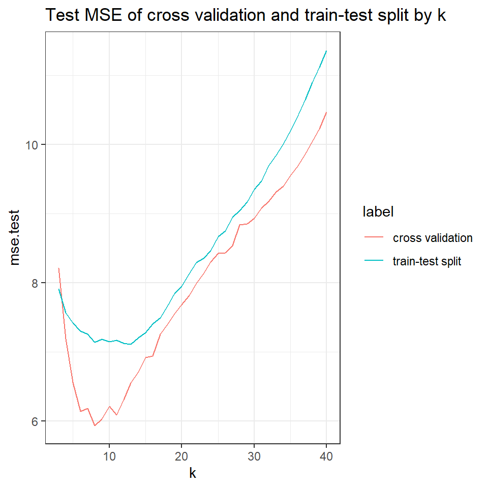

```r
split_knn <- data_knn2 %>% mutate(label = 'train-test split', edf = 90 / k)
cv_knn <- data_knn %>% group_by(k) %>%
  summarize(mse.test = mean(mse.test), label = 'cross validation') %>%
  mutate(edf = 90 / k)

ggplot() +
  geom_line(data = cv_knn, aes(x = k, y = mse.test, color = label)) +
  geom_line(data = split_knn, aes(x = k, y = mse.test, color = label)) +
  labs(title = "Test MSE of cross validation and train-test split by k")
```

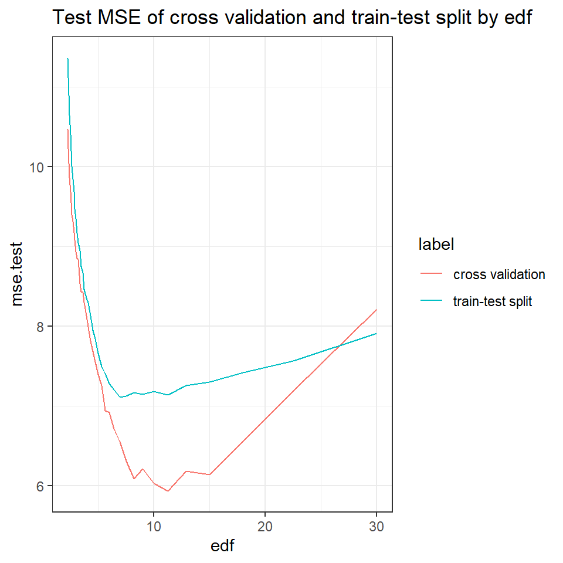

```r
ggplot() +
  geom_line(data = cv_knn, aes(x = edf, y = mse.test, color = label)) +
  geom_line(data = split_knn, aes(x = edf, y = mse.test, color = label)) +
  labs(title = "Test MSE of cross validation and train-test split by edf")
```